# Cost-effectiveness acceptability curve plots

## Introduction

The intention of this vignette is to show how to plot different styles of cost-effectiveness acceptability curves using the BCEA package.

## Two interventions only

This is the simplest case, usually an alternative intervention ($i=1$) versus status-quo ($i=0$).

The plot show the probability that the alternative intervention is cost-effective for each willingness to pay, $k$,

$$p(NB_1 \geq NB_0 | k) \mbox{ where } NB_i = ke - c$$

Using the set of $N$ posterior samples, this is approximated by

$$\frac{1}{N} \sum_j^N \mathbb{I} (k \Delta e^j - \Delta c^j)$$

#### R code

To calculate these in BCEA we use the `bcea()` function.

```r
data("Vaccine")

he <- bcea(e, c)
```

```
#> No reference selected. Defaulting to first intervention.
```

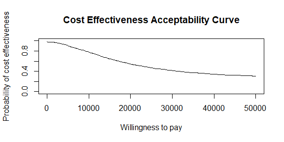

```r
# str(he)

ceac.plot(he)
```

The plot defaults to base R plotting. Type of plot can be set explicitly using the `graph` argument.

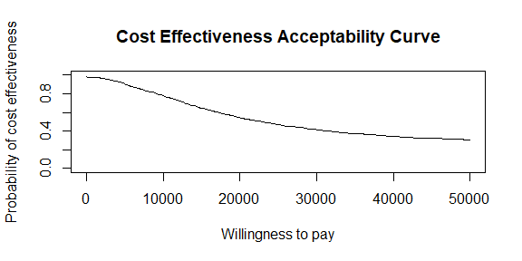

```r
ceac.plot(he, graph = "base")
```

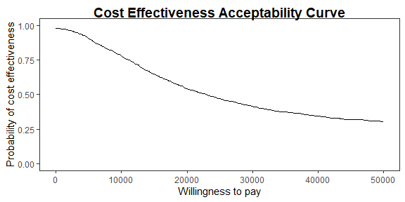

```r
ceac.plot(he, graph = "ggplot2")
```

```r
# ceac.plot(he, graph = "plotly")
```

Other plotting arguments can be specified such as title, line colours and theme.

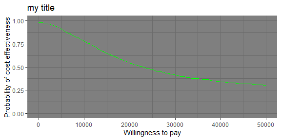

```r
ceac.plot(he,
          graph = "ggplot2",
          title = "my title",
          line = list(colors = "green"),
          theme = theme_dark())
```

## Multiple interventions

This situation is when there are more than two interventions to consider. Incremental values can be obtained either always against a fixed reference intervention, such as status-quo, or for all pair-wise comparisons.

### Against a fixed reference intervention

Without loss of generality, if we assume that we are interested in intervention $i=1$, then we wish to calculate

$$p(NB_1 \geq NB_s | k) \;\; \exists \; s \in S$$

Using the set of $N$ posterior samples, this is approximated by

$$\frac{1}{N} \sum_j^N \mathbb{I} (k \Delta e_{1,s}^j - \Delta c_{1,s}^j)$$

#### R code

This is the default plot for `ceac.plot()` so we simply follow the same steps as above with the new data set.

```r
data("Smoking")

he <- bcea(e, c, ref = 4)
# str(he)
```

```r
ceac.plot(he)
```

[output not shown]

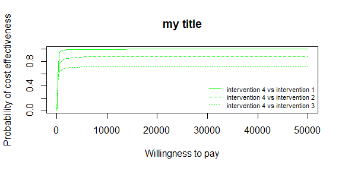

```r
ceac.plot(he,
          graph = "base",
          title = "my title",
          line = list(colors = "green"))
```

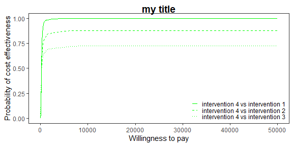

```r
ceac.plot(he,
          graph = "ggplot2",
          title = "my title",
          line = list(colors = "green"))
```

Reposition legend.

```r
ceac.plot(he, pos = FALSE) # bottom right
```

[output not shown]

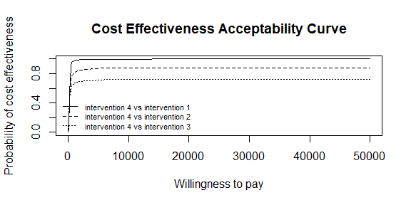

```r
ceac.plot(he, pos = c(0, 0))
```

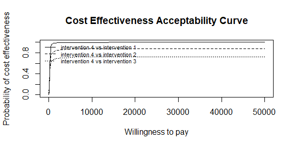

```r
ceac.plot(he, pos = c(0, 1))
```

```r
ceac.plot(he, pos = c(1, 0))
```

[output not shown]

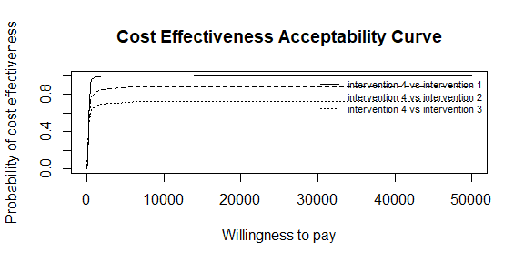

```r
ceac.plot(he, pos = c(1, 1))
```

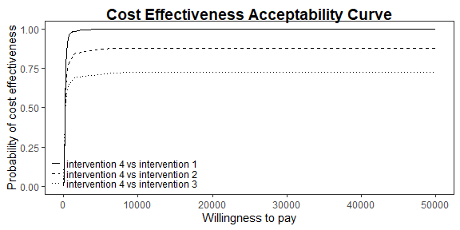

```r
ceac.plot(he, graph = "ggplot2", pos = c(0, 0))
```

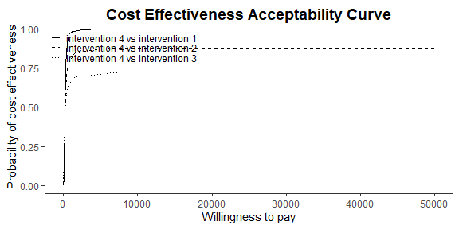

```r
ceac.plot(he, graph = "ggplot2", pos = c(0, 1))
```

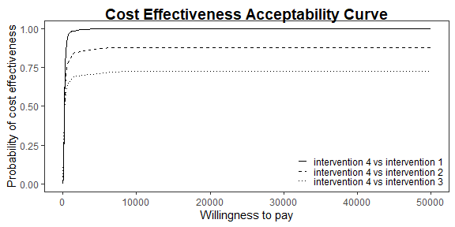

```r
ceac.plot(he, graph = "ggplot2", pos = c(1, 0))
```

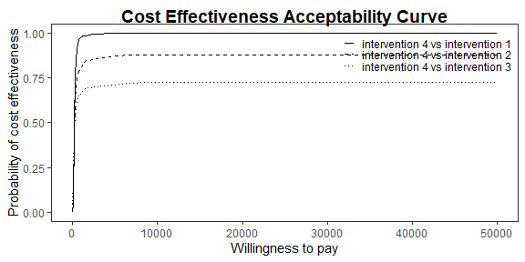

```r
ceac.plot(he, graph = "ggplot2", pos = c(1, 1))
```

Define colour palette.

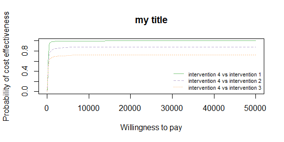

```r
mypalette <- RColorBrewer::brewer.pal(3, "Accent")

ceac.plot(he,
          graph = "base",
          title = "my title",
          line = list(colors = mypalette),
          pos = FALSE)
```

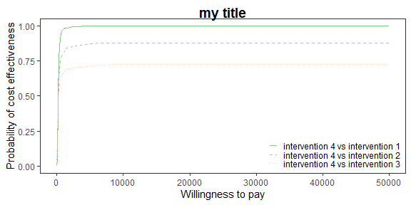

```r
ceac.plot(he,
          graph = "ggplot2",
          title = "my title",
          line = list(colors = mypalette),
          pos = FALSE)
```

### Pair-wise comparisons

Again, without loss of generality, if we assume that we are interested in intervention $i=1$, then we wish to calculate

$$p(NB_1 = \max\{NB_i : i \in S\} | k)$$

This can be approximated by the following.

$$\frac{1}{N} \sum_j^N \prod_{i \in S} \mathbb{I} (k \Delta e_{1,i}^j - \Delta c_{1,i}^j)$$

#### R code

In BCEA we first we must determine all combinations of paired interventions using the `multi.ce()` function.

```r
he <- multi.ce(he)
```

We can use the same plotting calls as before i.e. `ceac.plot()` and BCEA will deal with the pairwise situation appropriately. Note that in this case the probabilities at a given willingness to pay sum to 1.

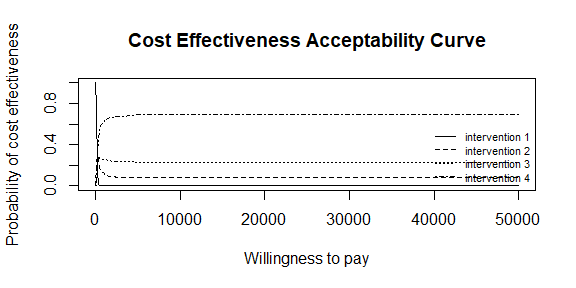

```r
ceac.plot(he, graph = "base")
```

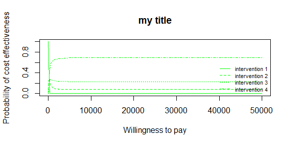

```r
ceac.plot(he,
          graph = "base",
          title = "my title",
          line = list(colors = "green"),
          pos = FALSE)
```

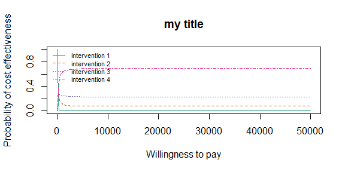

```r
mypalette <- RColorBrewer::brewer.pal(4, "Dark2")

ceac.plot(he,
          graph = "base",
          title = "my title",
          line = list(colors = mypalette),
          pos = c(0,1))
```

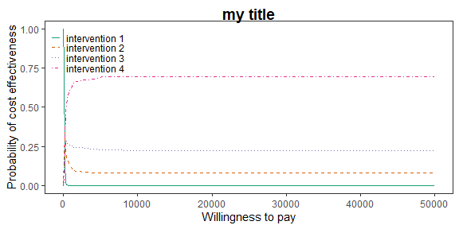

```r
ceac.plot(he,
          graph = "ggplot2",
          title = "my title",
          line = list(colors = mypalette),
          pos = c(0,1))
```